# Mapas de delitos patrimoniales y extorsión

Carlos Crespín

2024-04-30

```r
library(dplyr)
library(magrittr)
library(rio)
library(sp)
```

```r
library(ggplot2)
library(rgdal)
library(ggplot2)
library(sf)
```

En este trabajo de investigación se analiza, de manera preliminar, los delitos patrimoniales. En específico, se analizarán los delitos patrimoniales en el Perú y su desarrollo. Por el momento, se está trabajando con información obtenida por el Sistema de Control y Registro de Denuncias Policiales (SIDPOL). En ese sentido, la información obtenida de dicha base de datos corresponde a denuncias policiales, no a encuestas de victimización. Se trabajará acerca de ello más adelante.

Para poder conocer, de manera superficial, en qué zonas del Perú hay mayor inci- dencia de delitos patrimoniales y, especialmente, de extorsión, se realizará un análisis de la información recabada. Se tiene presente la existencia de un sub- registro de denuncias que no necesariamente se condice con los hechos delictivos en total que acontecen en el Perú. No obstante, esta información indica, en cier- ta medida, qué tanto puede confiar la población en la Policía Nacional del Perú como insitución y, por otro lado, la eficiencia de la misma.

La información se obtuvo del [Observatorio Nacional de Seguridad Ciudadana](https://observatorio.mininter.gob.pe/content/base-de-datos). Dicho observatorio contiene información proveniente de SIDPOL y otros portales de registro de la Policía. También contiene información de ENAPRES y de SIUP. Con dichas bases de datos también se trabajará puesto que ENAPRES tiene un apar- tado de victimización en su encuesta. En ese sentido, toma la forma de un cues- tionario sobre victimización. Por otro lado, el Sistema de Unidades Policiales contiene información acerca del número de efectivos policiales y dependencias de esta institución a nivel nacional.

Para este análisis inicial, se dividirá en dos apartados. El primero corresponde a un análisis provincial acerca de los delitos patrimoniales en general. En este se explorará la información referente a los tipos de delitos cometidos en el Perú y se desagregará tanto los tipos de delitos y la distribución de los mismos, así como la localización mayoritaria de los tipos de delitos.

En segundo lugar, se analizarán las denuncias por extorsión a nivel departamental y como se ha dispersado a nivel departamental. En ambos casos se trabaja con la data disponible del Observatorio.

# Información acerca de los tipos de delitos a nivel nacional

```r
delitos=import("C:/Users/Carlos Daniel/Documents/Tesis_de_Licenciatura/Delincuencia_en_el_Peru/SIDPOL/SIDPOL_2018-2024.xlsx")
```

Ahora bien, se procederá a realizar un análisis exploratorio acerca de la infor- mación que nos otorga la base de datos en materia de información por denuncias.

```r
names(delitos)
```

```
## [1] "ANIO"              "MES"               "DPTO_HECHO_NEW"
## [4] "PROV_HECHO"        "DIST_HECHO"        "UBIGEO_HECHO"
## [7] "PRINCIPALES_TIPOS" "n_dist_ID_DGC"     "DIST_EMERGENCIA"
```

Se puede apreciar las variables. Se les cambiará el nombre para mayores facili- dades. Asimismo, se preprocesará la data puesto que se desea analizar los tipos de delitos y la información correspondiente a estos.

```r
names(delitos)=c("year","mes","departamento","provincia","distrito","ubigeo","tipos","denuncias","distrito_emergencia")
```

Ahora, como se desea analizarlos tipos. veamos numéricamente qué tan distintos son las cantidades en los tipos de delitos.

```r
table(delitos$tipos)
```

```
##
##     Delitos contra la administración pública
##                                        21430
##                   Delitos contra la libertad
##                                        40598
##          Delitos contra la seguridad pública
##                                        30035
## Delitos contra la vida, el cuerpo y la salud
##                                        48639
##                        Delitos patrimoniales
##                                        61122
##                                Otros delitos
##                                        23347
```

No obstante, la información presentada solo es el recuento de cuántas veces se repiten esos tipos de delitos a lo largo de la base. No obstante, lo que se dese- a obtener es información que permita comparar dichos delitos. Para ello, realiza- remos distintas pruebas gráficas.

```r
library(lsr)
```

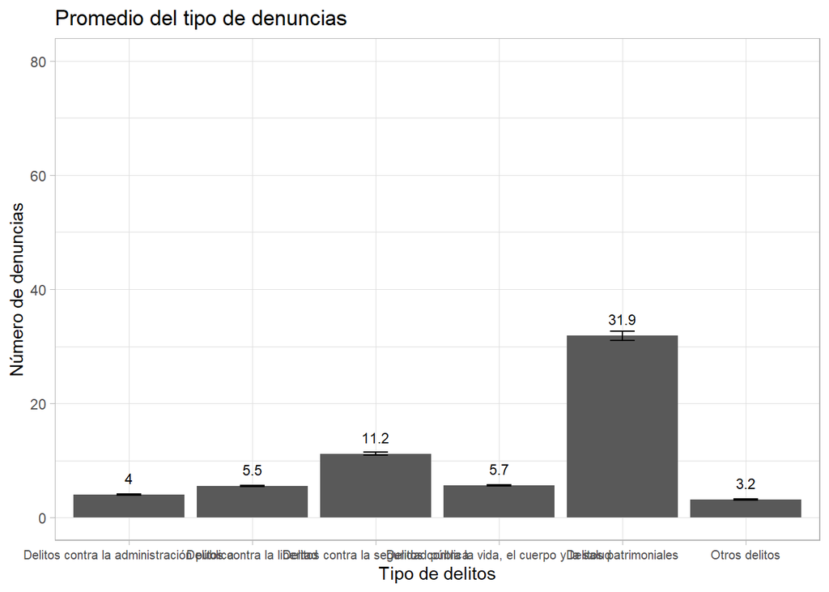

```r
IC_tipo = delitos |>
  group_by(tipos) |>
  summarise(media = mean(denuncias, na.rm=T),
            liminf = ciMean(denuncias, na.rm=T)[1],
            limsup = ciMean(denuncias, na.rm=T)[2]
            )


graf1 = ggplot(IC_tipo, aes(x=tipos, y=media))+
  geom_bar(stat="identity")+
  geom_errorbar(aes(ymin=liminf, ymax=limsup), width=0.2)+
  geom_text(aes(label=paste(round(media, 1))), vjust=-1, size=3)+
  xlab("Tipo de delitos") + ylab("Número de denuncias")+
  ylim(0, 80) +
  ggtitle("Promedio del tipo de denuncias") +
  theme_light() +
  theme(axis.text.x = element_text(size = 7.5))
graf1
```

Se puede observar que el tipo de delito con un mayor promedio son los de tipo patrimonial. En esta categoría se encuentran los delitos por hurto, robo, estafa, y extorsión. No obstante, no podemos quedarnos solo con esta información, pues es necesario conocer la distribución numérica de estos delitos para poder reali- zar mayores precisiones.

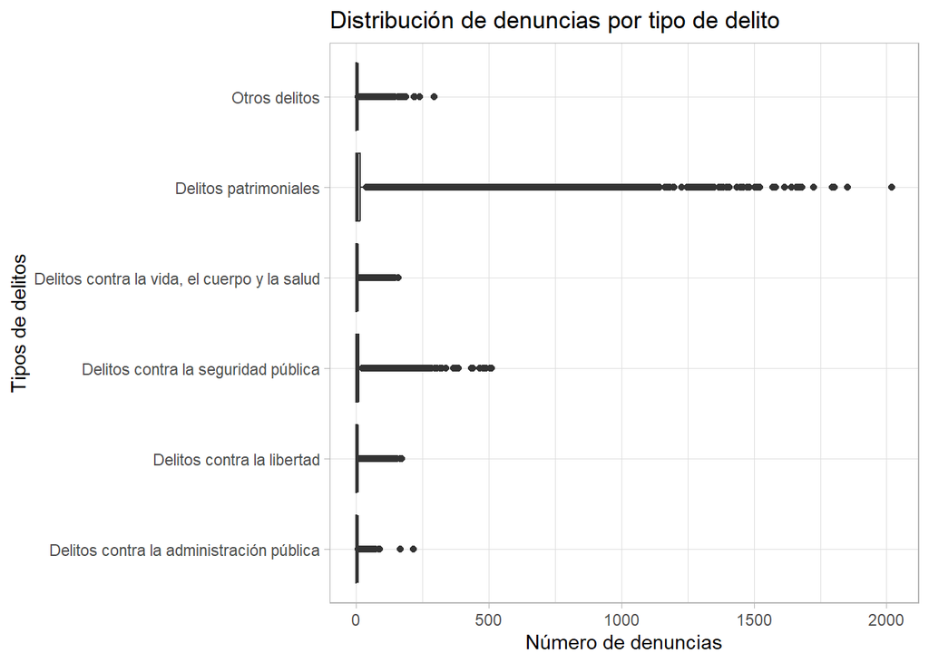

```r
ggplot(delitos, aes(x = tipos, y = denuncias)) +
  geom_boxplot() + coord_flip() +
  theme_light() +
  labs(x = "Tipos de delitos", y = "Número de denuncias") +
  ggtitle("Distribución de denuncias por tipo de delito")
```

Se puede apreciar que, si bien es cierto que a nivel visual no hay diferencias significativas en las muestras, se puede observar que, en el caso de los delitos patrimoniales, hay una mayor cantidad de valores atípicos y que se extienden en gran medida a lo largo del gráfico. Cabe recalcar que esta data contiene informa- ción de los años 2018 al 2024.

Entonces, se puede concluir que el número de denuncias por delitos patrimoniales es mucho mayor que el resto. Además, la distribución de estos datos es atípica y se expande más allá del rango intercuartílico.

Este elevado número de denuncias por delitos patrimoniales permite establecer una clara importancia en el estudio de estos temas para el análisis en materia de seguridad ciudadana. Este registro evidencia que la importancia de dichos delitos incluso si se toma en consideración la existencia de datos subregistrados a causa de la desconfianza en la policía.

# Los delitos patrimoniales a nivel nacional y su desagregación a nivel provincial

Ahora bien, tras resaltar la importancia de los delitos patrimoniales puesto que son los que más perjudican a la población al punto de ser altamente denunciados, se analizará el cómo estos delitos patrimoniales se distribuyen en las diferentes provincias del Perú. Puesto que la data ya se procesó de modo que la unidad de análisis sean dichas unidades territoriales, se descargará la data. Este pre-procesamiento se realizó en el archivo “cleandata.rmd”.

```r
patrimoniales=import("~/Tesis_de_Licenciatura/Delincuencia_en_el_Peru/SIDPOL/SIDPOL_provincias_patrimoniales/patrimoniales.csv") #data de todos los delitos patrimoniales por distrito desde 2018 hasta 2024
provincias_totales=import("~/Tesis_de_Licenciatura/Delincuencia_en_el_Peru/SIDPOL/SIDPOL_provincias_patrimoniales/provincias_totales.csv")#contiene información de las provincias y las denuncias por delitos patrimoniales a nivel histórico pero con 195 observaciones
provincias_allyears=import("~/Tesis_de_Licenciatura/Delincuencia_en_el_Peru/SIDPOL/SIDPOL_provincias_patrimoniales/provincias_allyears.csv")#información del total de denuncias por delitos patrimoniales a nivel histórico pero sin contar con Lima y otra provincia
panel_provincias=import("~/Tesis_de_Licenciatura/Delincuencia_en_el_Peru/SIDPOL/SIDPOL_provincias_patrimoniales/panel_provincias.csv")#este es un panel de datos que contiene información acerca de delitos patrimoniales por provincias desde 2018 hasta 2024
```

Primero analizaremos la distribución total de los datos en el gráfico total.

```r
library(ggplot2)
(statVals=summary(patrimoniales$denuncias))
```

```
##    Min. 1st Qu.  Median    Mean 3rd Qu.    Max.
##    1.00    1.00    4.00   31.89   16.00 2020.00
```

```r
statVals['std']=sd(patrimoniales$denuncias,na.rm = T)
(statVals=ceiling(statVals))
```

```
##    Min. 1st Qu.  Median    Mean 3rd Qu.    Max.     std
##       1       1       4      32      16    2020     101
```

[figure not shown]

```r
IQR=statVals['3rd Qu.']-statVals['1st Qu.']
statVals['upper']=1.5*IQR + statVals['3rd Qu.']
statVals['lower']=statVals['1st Qu.']-1.5*IQR
theStart=statVals['Min.']
width=10
oldMax=statVals['Max.']
newMax=ifelse(oldMax%%width<width,
              oldMax+(width-oldMax%%width),oldMax)
TheBreaks=seq(theStart,newMax,width)
intervals=cut(patrimoniales$denuncias,
              breaks=TheBreaks,include.lowest = T)
topCount=max(table(intervals))
widthY=50
top_Y=ifelse(topCount%%widthY<widthY,
             topCount+widthY-topCount%%widthY,topCount)
vertiVals=seq(0,top_Y,widthY)


histdenun= ggplot(patrimoniales, aes(x = denuncias)) +
  theme_classic() +
  ylab("Número de denuncias")
 disp3= histdenun + geom_histogram(binwidth = width,
                                   boundary=theStart,
                                   fill='white',color='grey60')
 # the normal curve
disp3= disp3 + stat_function(fun = "NormalHist",
                             color = "black", linewidth = 1,linetype='dashed')
 # the vertical axis values
disp3= disp3 + scale_y_continuous(breaks = vertiVals)
disp3
```

Se puede apreciar que la mayoría de distritos concentra un número reducido de denuncias por delitos patrimoniales.Ahora bien, visualizaremos, a través de la georreferencia, en qué provincias, desde 2018 hasta 2024, hubo más delitos patrimoniales

## Mapas de delitos patrimoniales a nivel nacional por provincias

Ahora bien, se realizará dichos mapas para identificar las provincias con mayor cantidad de denuncias por delitos patrimoniales.

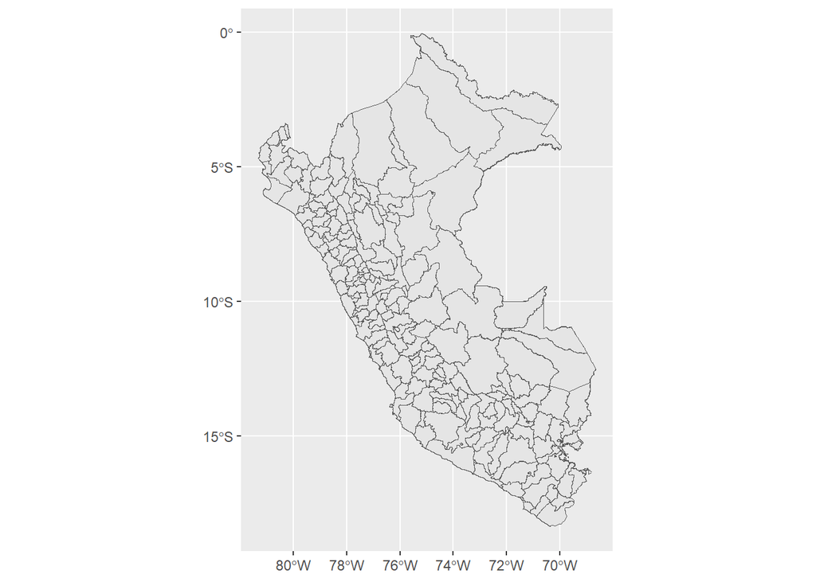

```r
mapPROV_total=read_sf("~/Tesis_de_Licenciatura/Delincuencia_en_el_Peru/provincias/provincias_totales.gpkg",layer="provincias")
mapPROV=sf::read_sf("~/Tesis_de_Licenciatura/Delincuencia_en_el_Peru/provincias/PROVINCIAS.shp")
ggplot(mapPROV)+geom_sf()
```

Puesto que la data se procesó en el archivo jupyter, se importará la data creada

```r
library(viridis)
```

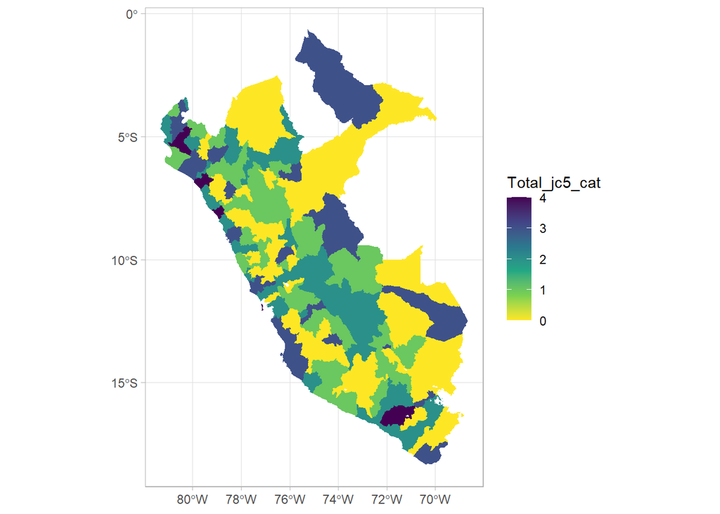

```r
#debido a que en python el método que mejores resultados otorgó fue el de JenksCaspall, se utilizará esa información
# Crea el gráfico
ggplot(data = mapPROV_total) +
  theme_light() +
  geom_sf(aes(fill = Total_jc5_cat), color = NA) +
  scale_fill_viridis_c(option = "D", direction = -1)
```

Este primer coropleto muestra la información que se obtuvo del modelo del JenksCaspall. Ahora bien, se realizará un mapa de calor que muestre de otro modo la informacion. En el primer coropleto se usa dicho algoritmo mientras que en el segundo a realizar se utiliza la información de las denuncias.

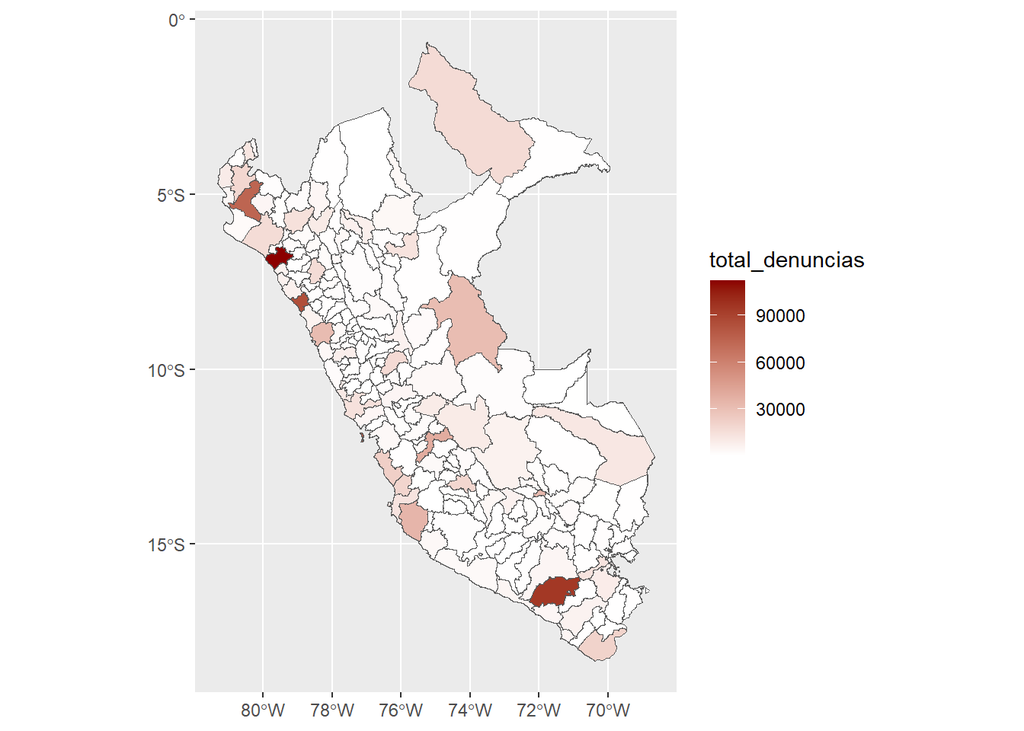

```r
# Crear el gráfico de mapa de calor
grafico <- ggplot(mapPROV_total) +
  geom_sf(aes(fill = total_denuncias)) +
  scale_fill_gradient(low = "white", high = "darkred")  # Invertir la escala de colores

# Mostrar el gráfico
print(grafico)
```

Se puede apreciar una gran diferencia entre ambos mapas puesto que, en el primero, se muestra en tonos azules más oscuros la información acerca de la data. En cambio, en el segundo, la escala de colores aumenta cuando se superan las noventa mil denuncias.

Una precisión a realizar es que la provincia de Putumayo no se encontraba en la data de delitos patrimoniales ni de extorsión, por tanto, no se puede visualizar la información. El espacio en blanco grande en el departamento de Loreto corresponde a Putumayo.

# Los delitos por extorsión en el Perú a nivel departamental

Ahora bien, se realizará un mapa a nivel departamental con los denuncias por delitos de extorsión en el Perú. Más adelante se procesará la información necesa- ria para poder obtener información mucho más desagregada a nivel provincial y distrital

Este es el mapa que se obtuvo

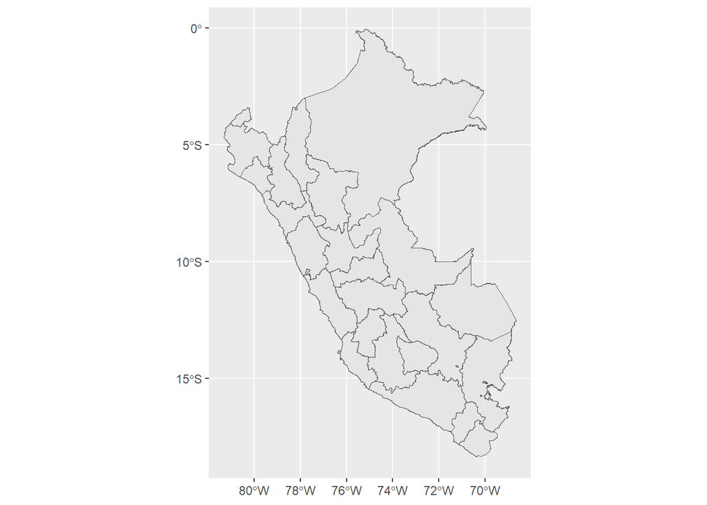

```r
library(sp)
library(ggplot2)
mapDPT=sf::read_sf("C:/Users/Carlos Daniel/Documents/Tesis_de_Licenciatura/Delincuencia_en_el_Peru/departamentos/DEPARTAMENTO.shp")
ggplot(mapDPT) + geom_sf()
```

Ahora se importará la data obtenida a nivel historico sobre dichos delitos.

```r
extor_total=import("~/Tesis_de_Licenciatura/Delincuencia_en_el_Peru/SIDPOL/SIDPOL_departamentos_extorsion/ext_total.csv")
#se cambiará de nombre a las columnas para poder realizar el merge
names(extor_total)=c("DEPARTAMEN","denuncias_extor")
```

Se procederá con el merge correspondiente a este mapa para realizar las pruebas

```r
geoextor=merge(mapDPT, extor_total)
```

Tras haber realizado el merge, se realizará el mapa respectivo

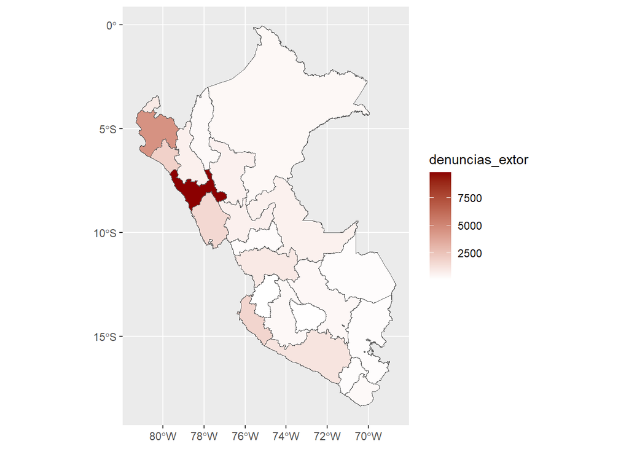

```r
# Crear el gráfico de mapa de calor
DPT_extor <- ggplot(geoextor) +
  geom_sf(aes(fill = denuncias_extor)) +
  scale_fill_gradient(low = "white", high = "darkred")  # Invertir la escala de colores

# Mostrar el gráfico
print(DPT_extor)
```

# Variación de las denuncias por delitos por extorsión por año

```r
den_mod=import("https://github.com/krlos20203563/Delincuencia_en_el_Peru/raw/main/SIDPOL/SIDPOL_dpt_extorsion.xlsx")
ext_years=filter(den_mod, PMODALIDADES=="Extorsión")
ext_years=ext_years%>%
  group_by(ANIO)%>%
  summarise(n_extor=sum(n_dist_ID_DGC))
names(ext_years)=c("years","n_extor")
ext_years$years=as.numeric(ext_years$years)
```

Ahora se verificará cómo ha variado por año el número de denuncias por delitos de extorsión

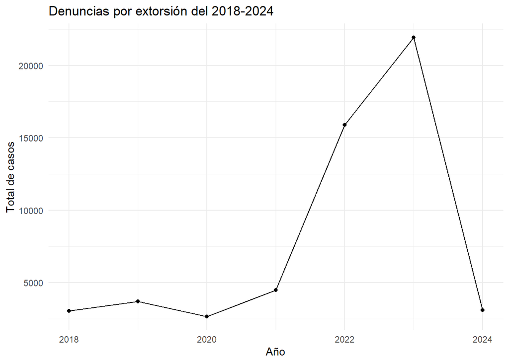

```r
ggplot(ext_years, aes(x = years, y = n_extor)) +
  geom_line() +
  geom_point() +
  labs(title = "Denuncias por extorsión del 2018-2024",
       x = "Año",
       y = "Total de casos") +
  theme_minimal()
```